# Genomic-wide association study (GWAS)

## Organizing the data for the GWAS

For the GWAS analysis, we going to organize the data. We will need dosage matrix (coded -1,0,1), phenotypes values for the trait of interest, and the QTL positions.

```r
# Genotypes/SNP matrix/dosage matrix
rawGeno = rawGeno-1
geno = as.data.frame(t(rawGeno))
geno = data.frame(snp=row.names(geno),
                  chr=rep(1:10,each=nSnpPerChr),
                  pos=rep(1:nSnpPerChr,10),
                  geno)

# Create "pheno" data.frames for rrBLUP
pheno = data.frame(gid=names(geno)[-(1:3)],
                   trait1=pop@pheno[,1])

# Tracking the information of population
phenoQ = data.frame(gid=pheno$gid,
                    subPop=factor(rep(c("a","b"),each=500)),
                    trait1=pheno$trait1)

# Find QTL locations within SNP chip and chromosome position
qtl =  paste0(rep(1:10, each = 10), '_',SP$traits[[1]]@lociLoc)
```

## Model 1 - GWAS with no adjustament

Single marker regression

$$y = S\alpha + e$$

```r
# No adjustments----
model0 = data.frame(snp=geno$snp,
                    chr=geno$chr,
                    pos=geno$pos,
                    trait1=rep(NA_real_,10*nSnpPerChr))

for(i in 1:(10*nSnpPerChr)){
  if(MAF[i]>=0.05){
    #Fit linear model with lm() and extract p-value
    mod1 = summary(lm(pheno$trait1~rawGeno[,i]))
    tmp = mod1[[4]][2,4]
    #Check for markers confounded with structure
    if(is.na(tmp)){
      model0$trait1[i] = 1
    }else{
      model0$trait1[i] = tmp
    }
  }else{
    model0$trait1[i] = 1
  }
}
#Account for p-value=0
model0$trait1[model0$trait1==0] = 1e-300
```

## Model 2 - GWAS correcting with population structure (Q)

Single marker regression with population as fixed effect

$$y = X\beta + S\alpha + e$$

```r
#Adjust for population structure (Q)----
modelQ = model0
for(i in 1:(10*nSnpPerChr)){
  if(MAF[i]>=0.05){
    #Fit linear model with lm() and extract p-value
    mod2 = summary(lm(pheno$trait1~phenoQ$subPop+rawGeno[,i]))[[4]]
    if(dim(mod2)[1] == 2){
      tmp = NA
    }else{
      tmp = mod2[3,4]
    }
    #Check for markers confounded with structure
    if(is.na(tmp)){
      modelQ$trait1[i] = 1
    }else{
      modelQ$trait1[i] = tmp
    }
  }else{
    modelQ$trait1[i] = 1
  }
}
#Account for p-value=0
modelQ$trait1[modelQ$trait1==0] = 1e-300
```

## Model 3 - GWAS correcting with Kinship matrix (K)

Single marker regression with covariance information among the individuals. The matrix will be calculated internally by the function ’A.mat`.

$$y = S\alpha + Qv + e$$

```r
#Adjust for kinship (K)----
modelK = GWAS(pheno,geno,plot=FALSE)
```

```
## [1] "GWAS for trait: trait1"
## [1] "Variance components estimated. Testing markers."
```

```r
modelK$trait1 = 10^(-modelK$trait1) #Revert to p-value
```

## Model 4 - GWAS correcting with both, Q and K

$$y = X\beta + S\alpha + Qv + e$$

```r
#Adjust for both structure and kinship (Q+K)----
modelQK = GWAS(phenoQ,geno,fixed="subPop",plot=FALSE)
```

```
## [1] "GWAS for trait: trait1"
## [1] "Variance components estimated. Testing markers."
```

```r
modelQK$trait1 = 10^(-modelQK$trait1) #Revert to p-value
```

## Manhattan plot

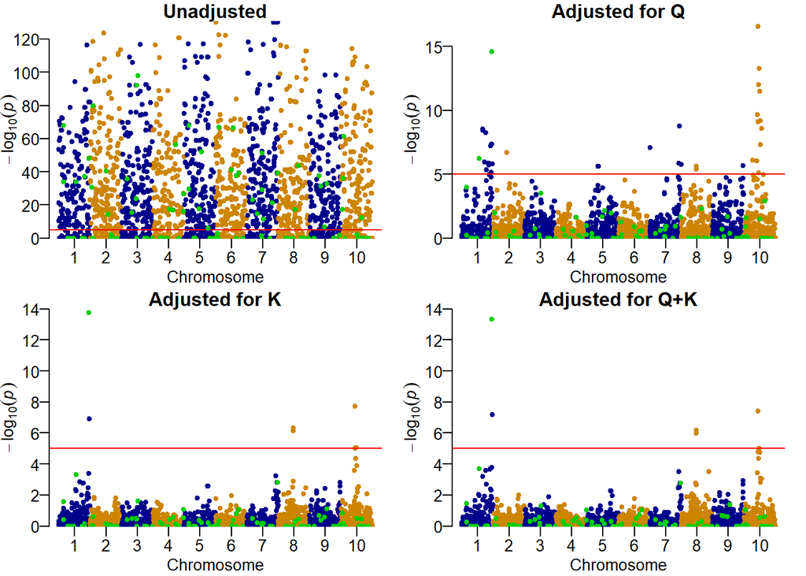

```r
# Assuming Bonferroni Threshold (0.05/m)
hline = -log10(0.05/ncol(rawGeno))

# Manhattan plots
op = par(mfrow=c(2,2),mai=c(.9,.9,0.9,0.9),
         mar=c(2.5,2.5,1,1)+0.1,
         mgp = c(1.5,0.5,0))

manhattan(model0,chr="chr",bp="pos",p="trait1",snp="snp",  highlight=qtl,
         main="Unadjusted", col = c("blue4", "orange3"),
          suggestiveline = FALSE, genomewideline = hline)
manhattan(modelQ,chr="chr",bp="pos",p="trait1",snp="snp",highlight=qtl,
          main="Adjusted for Q", col = c("blue4", "orange3"),
          suggestiveline = FALSE, genomewideline = hline)
manhattan(modelK,chr="chr",bp="pos",p="trait1",snp="snp",highlight=qtl,
          main="Adjusted for K", col = c("blue4", "orange3"),
          suggestiveline = FALSE, genomewideline = hline)
manhattan(modelQK,chr="chr",bp="pos",p="trait1",snp="snp",highlight=qtl,
          main="Adjusted for Q+K", col = c("blue4", "orange3"),
          suggestiveline = FALSE, genomewideline = hline)
```

## QQ-plot

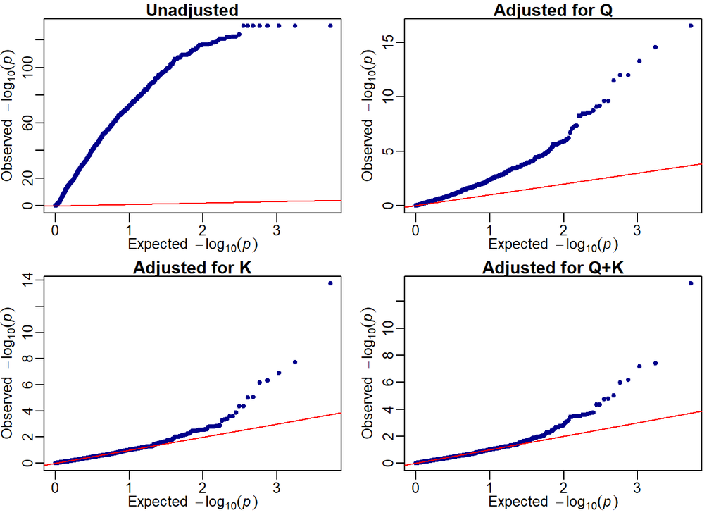

```r
#Q-Q plots
op = par(mfrow=c(2,2),mai=c(.9,.9,0.9,0.9),
         mar=c(2.5,2.5,1,1)+0.1,
         mgp = c(1.5,0.5,0))
qq(model0$trait1,main="Unadjusted", col = "blue4")
qq(modelQ$trait1,main="Adjusted for Q", col = "blue4")
qq(modelK$trait1,main="Adjusted for K", col = "blue4")
qq(modelQK$trait1,main="Adjusted for Q+K", col = "blue4")
```

## Extra Models with GAPIT

```r
# Create "pheno" data.frames for rrBLUP
myYp = data.frame(gid=pop@id,
                  trait1=pop@pheno[,1])


# Geno
rawGeno = pullSnpGeno(pop)
Markers = data.frame(myYp["gid"],rawGeno)
rownames(Markers) = NULL

# markers position
Map.pos = data.frame(snp=colnames(Markers[,-1]),
                     chr=rep(1:10,each=nSnpPerChr),
                     pos=rep(1:nSnpPerChr,10))


# Model MLMM

mod1=GAPIT(Y=myYp, #fist column is ID
           GD=Markers,
           GM=Map.pos,
           PCA.total=2,
           model="MLMM",  # MLMM
           Geno.View.output = FALSE,
           PCA.View.output=FALSE)

# Model FarmCPU

mod2=GAPIT(Y=myYp, #fist column is ID
           GD=Markers,
           GM=Map.pos,
           PCA.total=2,
           model="FarmCPU",  # MLMM
           Geno.View.output = FALSE,
           PCA.View.output=FALSE)

# Model MLM

mod3=GAPIT(Y=myYp, #fist column is ID
           GD=Markers,
           GM=Map.pos,
           PCA.total=2,
           model="MLM",  # MLMM
           Geno.View.output = FALSE,
           PCA.View.output=FALSE)
```

## References

Gaynor, R Chris, Gregor Gorjanc, and John M Hickey. 2021. “AlphaSimR: An r Package for Breeding Program Simulations.” *G3* 11 (2): jkaa017.

Wang, Jiabo, and Zhiwu Zhang. 2021. “GAPIT Version 3: Boosting Power and Accuracy for Genomic Association and Prediction.” *Genomics, Proteomics & Bioinformatics* 19 (4): 629–40.

[^1]: University of Florida, mresende@ufl.edu
[^2]: University of Florida, deamorimpeixotom@ufl.edu